# **Visualizating PM2.5 Data**

by Xiang Wang in Summer 2015

### Introduction

Fine particulate matter (`PM2.5`) is an ambient air pollutant for which there is strong evidence that it is harmful to human health. In the United States, the Environmental Protection Agency (EPA) is tasked with setting national ambient air quality standards for fine PM and for tracking the emissions of this pollutant into the atmosphere. Approximatly every 3 years, the EPA releases its database on emissions of PM2.5. This database is known as the National Emissions Inventory (NEI). You can read more information about the NEI at the EPA National Emissions Inventory web site. For each year and for each type of PM source, the NEI records how many tons of PM2.5 were emitted from that source over the course of the entire year. The data that you will use for this assignment are for 1999, 2002, 2005, and 2008.

### Data

The data for this assignment are available from the website: https://d396qusza40orc.cloudfront.net/exdata/data/NEI_data.zip The zip file contains two files: PM2.5 Emissions Data (summarySCC_PM25.rds) and Source Classification Code Table (Source_Classification_Code.rds).

PM2.5 Emissions Data: This file contains a data frame with all of the PM2.5 emissions data for 1999, 2002, 2005, and 2008. For each year, the table contains number of tons of PM2.5 emitted from a specific type of source for the entire year.

- fips: A five-digit number (represented as a string) indicating the U.S. county
- SCC: The name of the source as indicated by a digit string (see source code classification table)
- Pollutant: A string indicating the pollutant
- Emissions: Amount of PM2.5 emitted, in tons
- type: The type of source (point, non-point, on-road, or non-road)
- year: The year of emissions recorded

Source Classification Code Table: This table provides a mapping from the SCC digit strings in the Emissions table to the actual name of the PM2.5 source. The sources are categorized in a few different ways from more general to more specific.

### Data Preparation

```r
# Load RDS
NEI <- readRDS("summarySCC_PM25.rds")
SCC <- readRDS("Source_Classification_Code.rds")
str(NEI)
```

```
## 'data.frame':    6497651 obs. of  6 variables:
##  $ fips     : chr  "09001" "09001" "09001" "09001" ...
##  $ SCC      : chr  "10100401" "10100404" "10100501" "10200401" ...
##  $ Pollutant: chr  "PM25-PRI" "PM25-PRI" "PM25-PRI" "PM25-PRI" ...
##  $ Emissions: num  15.714 234.178 0.128 2.036 0.388 ...
##  $ type     : chr  "POINT" "POINT" "POINT" "POINT" ...
##  $ year     : int  1999 1999 1999 1999 1999 1999 1999 1999 1999 1999 ...
```

```r
str(SCC)
```

```
## 'data.frame':    11717 obs. of  15 variables:
##  $ SCC                : Factor w/ 11717 levels "10100101","10100102",..: 1 2 3 4 5 6 7 8 9 10 ...
##  $ Data.Category      : Factor w/ 6 levels "Biogenic","Event",..: 6 6 6 6 6 6 6 6 6 6 ...
##  $ Short.Name         : Factor w/ 11238 levels "","2,4-D Salts and Esters Prod /Process Vents, 2,4-D Recovery: Filtration",..: 3283 3284 3293 3291 3290 3294 3295 3296 3292 3289 ...
##  $ EI.Sector          : Factor w/ 59 levels "Agriculture - Crops & Livestock Dust",..: 18 18 18 18 18 18 18 18 18 18 ...
##  $ Option.Group       : Factor w/ 25 levels "","C/I Kerosene",..: 1 1 1 1 1 1 1 1 1 1 ...
##  $ Option.Set         : Factor w/ 18 levels "","A","B","B1A",..: 1 1 1 1 1 1 1 1 1 1 ...
##  $ SCC.Level.One      : Factor w/ 17 levels "Brick Kilns",..: 3 3 3 3 3 3 3 3 3 3 ...
##  $ SCC.Level.Two      : Factor w/ 146 levels "","Agricultural Chemicals Production",..: 32 32 32 32 32 32 32 32 32 32 ...
##  $ SCC.Level.Three    : Factor w/ 1061 levels "","100% Biosolids (e.g., sewage sludge, manure, mixtures of these matls)",..: 88 88 156 156 156 156 156 156 156 156 ...
##  $ SCC.Level.Four     : Factor w/ 6084 levels "","(NH4)2 SO4 Acid Bath System and Evaporator",..: 4455 5583 4466 4458 1341 5246 5584 5983 4461 776 ...
##  $ Map.To             : num  NA NA NA NA NA NA NA NA NA NA ...
##  $ Last.Inventory.Year: int  NA NA NA NA NA NA NA NA NA NA ...
##  $ Created_Date       : Factor w/ 57 levels "","1/27/2000 0:00:00",..: 1 1 1 1 1 1 1 1 1 1 ...
##  $ Revised_Date       : Factor w/ 44 levels "","1/27/2000 0:00:00",..: 1 1 1 1 1 1 1 1 1 1 ...
##  $ Usage.Notes        : Factor w/ 21 levels ""," ","includes bleaching towers, washer hoods, filtrate tanks, vacuum pump exhausts",..: 1 1 1 1 1 1 1 1 1 1 ...
```

```r
levels(as.factor(NEI$year))
```

```
## [1] "1999" "2002" "2005" "2008"
```

```r
head(NEI)[1:3,]
```

```
##     fips      SCC Pollutant Emissions  type year
## 4  09001 10100401  PM25-PRI    15.714 POINT 1999
## 8  09001 10100404  PM25-PRI   234.178 POINT 1999
## 12 09001 10100501  PM25-PRI     0.128 POINT 1999
```

```r
head(SCC)[1:3,]
```

```
##        SCC Data.Category
## 1 10100101         Point
## 2 10100102         Point
## 3 10100201         Point
##                                                                   Short.Name
## 1                   Ext Comb /Electric Gen /Anthracite Coal /Pulverized Coal
## 2 Ext Comb /Electric Gen /Anthracite Coal /Traveling Grate (Overfeed) Stoker
## 3       Ext Comb /Electric Gen /Bituminous Coal /Pulverized Coal: Wet Bottom
##                                EI.Sector Option.Group Option.Set
## 1 Fuel Comb - Electric Generation - Coal
## 2 Fuel Comb - Electric Generation - Coal
## 3 Fuel Comb - Electric Generation - Coal
##                 SCC.Level.One       SCC.Level.Two
## 1 External Combustion Boilers Electric Generation
## 2 External Combustion Boilers Electric Generation
## 3 External Combustion Boilers Electric Generation
##                 SCC.Level.Three
## 1               Anthracite Coal
## 2               Anthracite Coal
## 3 Bituminous/Subbituminous Coal
##                                  SCC.Level.Four Map.To Last.Inventory.Year
## 1                               Pulverized Coal     NA                  NA
## 2             Traveling Grate (Overfeed) Stoker     NA                  NA
## 3 Pulverized Coal: Wet Bottom (Bituminous Coal)     NA                  NA
##   Created_Date Revised_Date Usage.Notes
## 1
## 2
## 3
```

### Data Visualization

#### Plot 1: a barplot showing the sum of emissions in kilotons by year

```r
# compute the sum of emissions in kilotons by year
Emissions <- aggregate(NEI[, 'Emissions'], by=list(NEI$year), FUN=sum, na.rm=TRUE)
Emissions$PM <- round(Emissions[,2]/1000, 1)
head(Emissions)
```

```
##   Group.1       x     PM
## 1    1999 7332967 7333.0
## 2    2002 5635780 5635.8
## 3    2005 5454703 5454.7
## 4    2008 3464206 3464.2
```

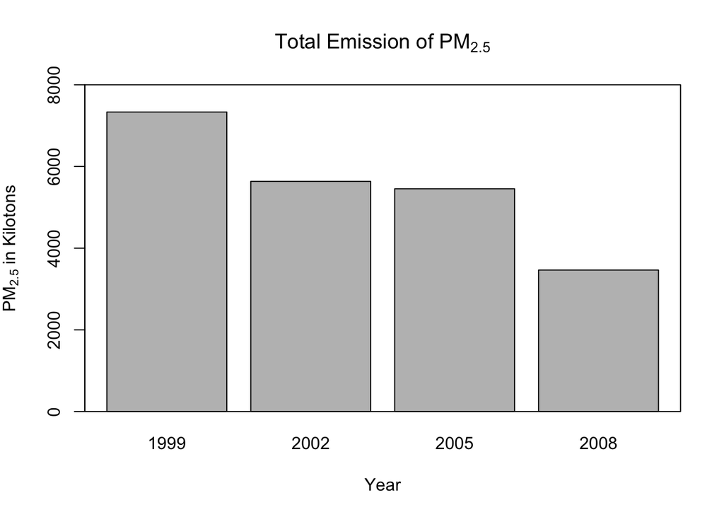

```r
# plot the sum of emissions in kilotons by year
barplot(Emissions$PM, names.arg=Emissions$Group.1, col = 'Grey', main=expression('Total Emission of PM'[2.5]), ylim=c(0, 8000), xlab = 'Year', ylab = expression(paste('PM', ''[2.5], ' in Kilotons'))); box(which="plot")
```

```r
## The total emissions from PM2.5 decreased in the United States from 1999 to 2008.
```

#### Plot 2: a barplot showing the sum of emissions in kilotons by year in Baltimore City, MD

```r
# subset the data for Baltimore City, MD
MD <- subset(NEI, fips=='24510')
str(MD)
```

```
## 'data.frame':    2096 obs. of  6 variables:
##  $ fips     : chr  "24510" "24510" "24510" "24510" ...
##  $ SCC      : chr  "10100601" "10200601" "10200602" "30100699" ...
##  $ Pollutant: chr  "PM25-PRI" "PM25-PRI" "PM25-PRI" "PM25-PRI" ...
##  $ Emissions: num  6.53 78.88 0.92 10.38 10.86 ...
##  $ type     : chr  "POINT" "POINT" "POINT" "POINT" ...
##  $ year     : int  1999 1999 1999 1999 1999 1999 1999 1999 1999 1999 ...
```

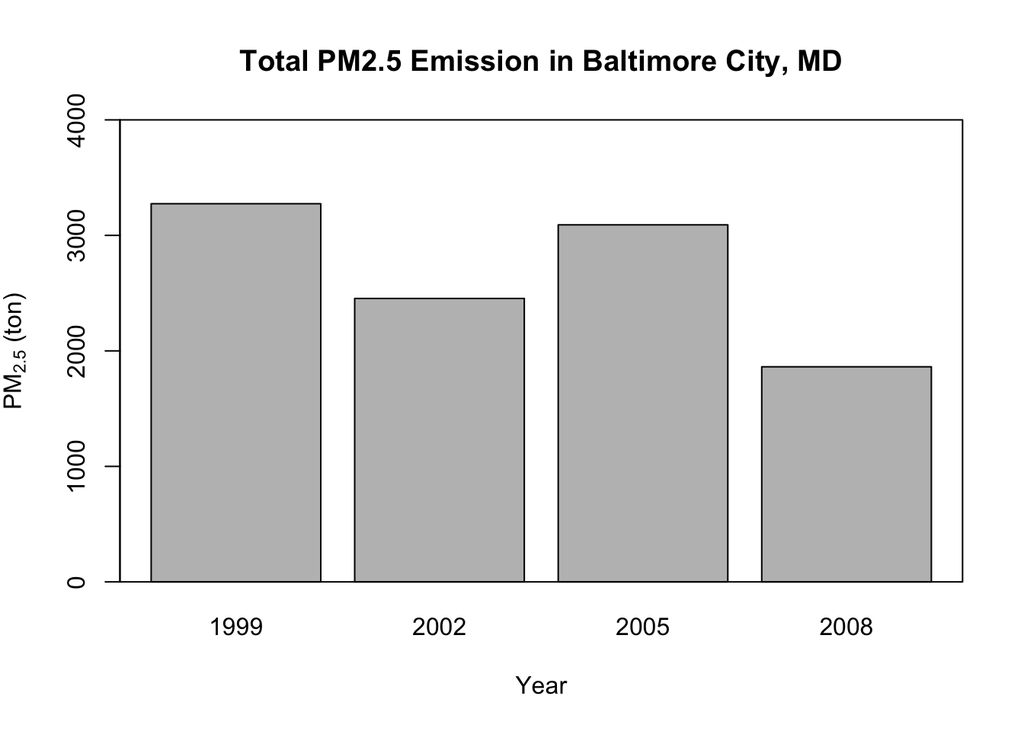

```r
# make the plot
barplot(tapply(X=MD$Emissions, INDEX=MD$year, FUN=sum), col='grey', main='Total PM2.5 Emission in Baltimore City, MD', yli=c(0, 4000), xlab='Year', ylab=expression(paste('PM', ''[2.5], ' (ton)'))); box(which="plot")
```

```r
## Generally, the total emissions from PM2.5 decreased in the Baltimore City, Maryland from 1999 to 2008.
```

#### Plot 3: a line plot showing the sum of emissions by year and type in Baltimore City, MD

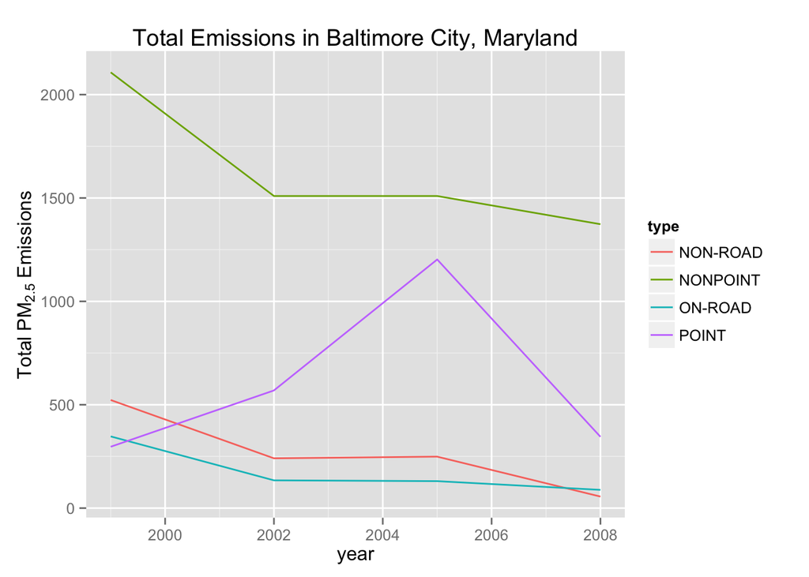

```r
# subset the data for Baltimore City, MD
MD <- subset(NEI, fips=='24510')
a <- aggregate(Emissions~year*type, MD, sum)
# make the plot
library(ggplot2) # loads ggplot2 package
g <- ggplot(a, aes(year, Emissions, color=type))
g <- g + geom_line() +
  xlab("year") +
  ylab(expression('Total PM'[2.5]*" Emissions")) +
  ggtitle('Total Emissions in Baltimore City, Maryland')
print(g)
```

```r
## Of the four types of *sources* indicated by the type variable, nonpoint, onroad and nonroad have seen decreases in emissions from 1999–2008 for Baltimore City; source of point has seen increases and then decrease in emissions.
```

#### Plot 4: a line plot showing coal-related emissions by year across US

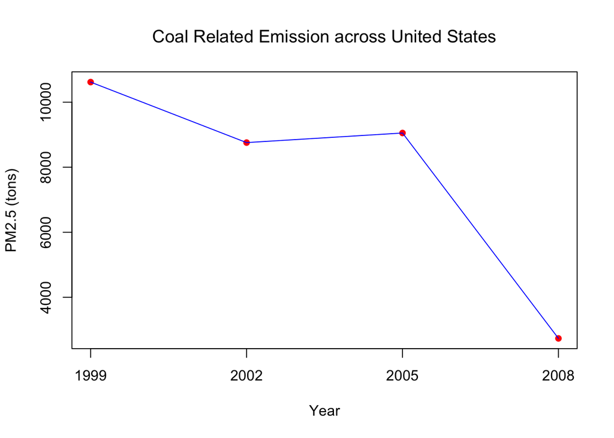

```r
# subset the data for coal-related emissions
Coal <- SCC[SCC$EI.Sector=="Fuel Comb - Comm/Institutional - Coal", ]["SCC"]
efc <- NEI[NEI$SCC %in% Coal$SCC, ]
# use tapply to calculate the total emissions each year due to coal across US
totalCoal <- tapply(efc$Emissions, efc$year, sum)
# make the plot
plot(totalCoal, x=rownames(totalCoal), type="n", axes=FALSE, ylab="PM2.5 (tons)", xlab="Year", main=expression("Coal Related Emission across United States"))
points(totalCoal, x=rownames(totalCoal), pch=16, col="red")
lines(totalCoal, x=rownames(totalCoal), col="blue")
axis(2); axis(side=1, at=seq(1999, 2008, by=3)); box()
```

```r
## Across the United States, total emissions from coal combustion-related sources decreased from 1999–2008.
```

#### Plot 5: a barplot showing total emissions from motor vehicle sources in Baltimore City, Maryland

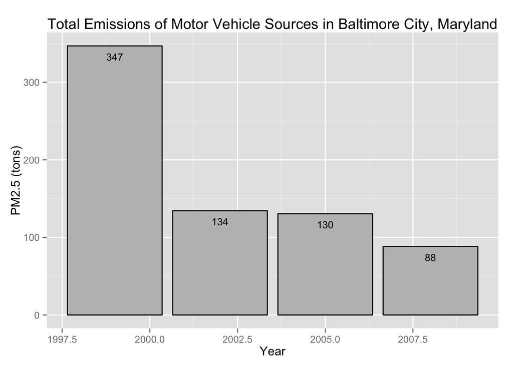

```r
# subset the data for motor vehicle sources in Baltimore City, MD
motor <- subset(NEI, fips==24510 & type=='ON-ROAD')
mv <- aggregate(motor[, 'Emissions'], by = list(motor$year), sum)
colnames(mv) <- c('year', 'Emissions')
# make the plot
h <- ggplot(data=mv, aes(x=year, y=Emissions))
h <- h + geom_bar(fill="grey", color="black", stat="identity") +
  guides(fill=F) +
  ggtitle('Total Emissions of Motor Vehicle Sources in Baltimore City, Maryland') +
  ylab('PM2.5 (tons)') +
  xlab('Year') +
  theme(legend.position='none') +
  geom_text(aes(label=round(Emissions, 0), size=1, hjust=0.5, vjust=2))
print(h)
```

```r
## Total emissions from motor vehicle sources decreased from 1999–2008 in Baltimore City.
```

#### Plot 6: a barplot showing total emissions from motor vehicle sources in Baltimore City, MD and Los Angeles, CA

```r
# subset and calculate the data for motor vehicle sources in Baltimore City, MD and Los Angeles, CA
MD <- subset(NEI, fips=='24510' & type=='ON-ROAD')
md <- aggregate(MD[, 'Emissions'], by=list(MD$year), sum)
colnames(md) <- c('year', 'Emissions')
md$City <- paste(rep('MD', 4))

CA <- subset(NEI, fips=='06037' & type=='ON-ROAD')
ca <- aggregate(CA[, 'Emissions'], by=list(CA$year), sum)
colnames(ca) <- c('year', 'Emissions')
ca$City <- paste(rep('CA', 4))

DF <- as.data.frame(rbind(md, ca))
str(DF)
```

```
## 'data.frame':    8 obs. of  3 variables:
##  $ year     : int  1999 2002 2005 2008 1999 2002 2005 2008
##  $ Emissions: num  346.8 134.3 130.4 88.3 3931.1 ...
##  $ City     : chr  "MD" "MD" "MD" "MD" ...
```

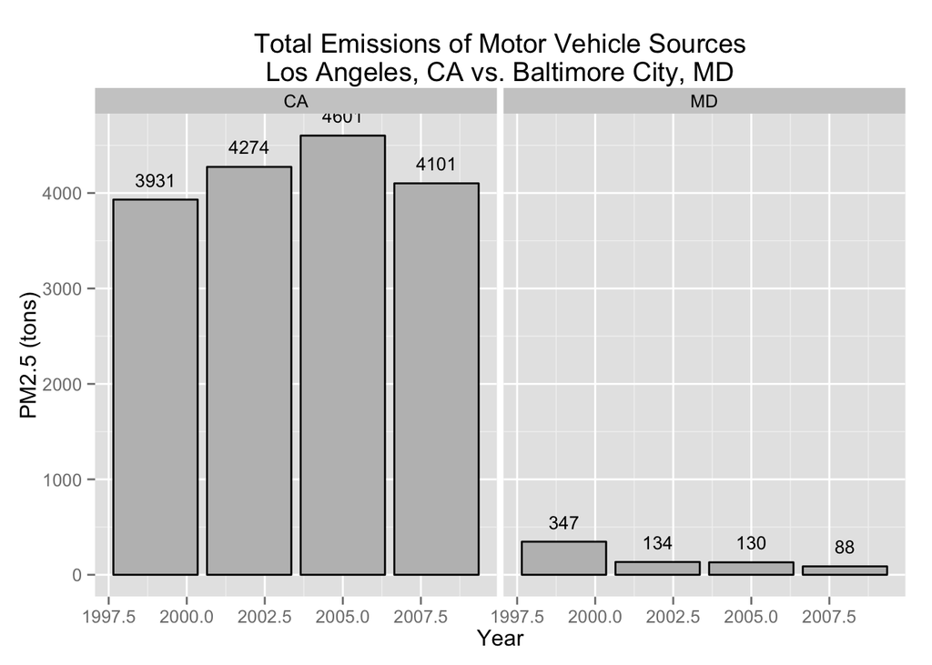

```r
# make the plot
d <- ggplot(data=DF, aes(x=year, y=Emissions))
d <- d + geom_bar(fill="grey", color="black",stat = "identity") +
  guides(fill=F) +
  ggtitle('Total Emissions of Motor Vehicle Sources\nLos Angeles, CA vs. Baltimore City, MD') +
  ylab('PM2.5 (tons)') +
  xlab('Year') +
  theme(legend.position='none') +
  facet_grid(. ~ City) +
  geom_text(aes(label=round(Emissions, 0), size=1, hjust=0.5, vjust=-1))
print(d)
```

```r
## Los Angeles County, California has seen much greater motor vehicle emissions over time.
```